# Lab10_SamikshaRajpal_8908982

### Lab 10 - Fine-Tune VGG16 for Bird Classification

#### Name: Samiksha Rajpal

#### Id: 8908982

- Obtain the Data
  - Download the BIRDS 525 SPECIES dataset from Kaggle (CC0 license). You will need to create a free Kaggle account, and this will provide you free access to many such datasets, as well as code and even online notebooks.
  - Unpack the data. Notice that the data is organized into folders in a way similar to the Dogs vs Cats dataset that we worked with. This makes it easy to load with the same Keras function (ImageDataGenerator.flow_from_directory).

```python
# Importing necessary packages
import os
import shutil
from tensorflow.keras.utils import image_dataset_from_directory
from keras.preprocessing.image import ImageDataGenerator
import numpy as np
import matplotlib.pyplot as plt
from tensorflow.keras.applications import VGG16
from tensorflow import keras
import tensorflow as tf
from tensorflow.keras import layers
from sklearn.metrics import accuracy_score, confusion_matrix, precision_score, recall_score, f1_score, classification_report, precision_recall_curve, auc
from keras.utils import to_categorical
import pathlib
from PIL import Image
import seaborn as sns
```

```python
# importing datasets
trainBirds = "/Users/samiksharajpal/Desktop/archive/train"
testBirds = "/Users/samiksharajpal/Desktop/archive/test"
validBirds = "/Users/samiksharajpal/Desktop/archive/valid"
```

For this lab, we will work with the 3 classes with the highest number of images. Identify those classes, and use only these for the next steps. You can delete/discard the others.

```python
# Initializing image counter in a dictionary
imageCounter = {} #creating dictionary for image counts

# creating a function to count images in a directory
def birdImageCounter(dir_path):
    lab10Bird = os.scandir(dir_path)
    lab10birdImages = 0
    for path in lab10Bird:
        if path.is_file():
            lab10birdImages += 1
    return lab10birdImages
```

```python
# creating function to count number of images in each sub-directory within a directory
def birdImagesCounterSubDir(sub_dir_path):
    for birdSubDir in os.scandir(sub_dir_path):
        if birdSubDir.is_dir():
            birdsDir = birdSubDir
            imageCounter[birdsDir] = birdImageCounter(birdSubDir.path)
```

```python
# Finding image counts for each class in the bird_train folder
birdImagesCounterSubDir(trainBirds)
```

```
None
```

```python
# Sorting it into descending order to find top classes
sortedBirdImages = sorted(imageCounter.items(), key=lambda item: item[1], reverse=True)
birdsTop3 = sortedBirdImages[:3]
```

```python
# Storing top 3 classes in a list for easy accessibility
birdsTop3class = []


# Setting top 3 classes with highest birds in list
for birdNameImg, count in birdsTop3:
    birdsTop3class.append(str(birdNameImg).split(" '")[1].replace("'>",""))

# Print top 3 classes with highest birds
print("Top 3 Class with highest number of birds are :",birdsTop3class, )
```

```
Top 3 Class with highest number of birds are : ['RUFOUS TREPE', 'HOUSE FINCH', 'OVENBIRD']
```

Copying top 3 classes to new folder named newBirds

```python
# Specify the path to your 'birds' folder
source = pathlib.Path('/Users/samiksharajpal/Desktop/archive')

# Specify the new path where you want to copy the selected classes
newSource = pathlib.Path('/Users/samiksharajpal/Desktop/archive/newBirds')

# Create new subfolders in the new structure
for subfolder in ['train', 'test', 'valid']:
    new_subfolder_path = newSource / subfolder
    new_subfolder_path.mkdir(parents=True, exist_ok=True)

# Loop through each subfolder
for subfolder in ['train', 'test', 'valid']:
    subfolder_path = source / subfolder

    # Loop through selected classes
    for selected_class in birdsTop3class:
        class_name = selected_class

        # Check if the class folder exists
        class_folder_path = subfolder_path / class_name
        if class_folder_path.exists():
            # Create a new folder in the new path
            new_class_folder_path = newSource / subfolder / class_name
            new_class_folder_path.mkdir(parents=True, exist_ok=True)

            # Copy all files from the original class folder to the new folder
            for file_name in os.listdir(class_folder_path):
                file_path = class_folder_path / file_name
                shutil.copy(file_path, new_class_folder_path)

# Print a message indicating that the copy is complete
print(f"Selected classes copied to {newSource}")
```

```
Selected classes copied to /Users/samiksharajpal/Desktop/archive/newBirds
```

Checking the image size

```python
# Specify the path to any image file
image_path = '/Users/samiksharajpal/Desktop/archive/newBirds/train/OVENBIRD/001.jpg'

# Open the image
with Image.open(image_path) as img:
    # Get the size of the image
    width, height = img.size
    print(f"Image size: {width} x {height}")
```

```
Image size: 224 x 224
```

Setting up train, test and validation paths

```python
train_path = "/Users/samiksharajpal/Desktop/archive/newBirds/train"
test_path = "/Users/samiksharajpal/Desktop/archive/newBirds/test"
valid_path = "/Users/samiksharajpal/Desktop/archive/newBirds/valid"
```

3. Instantiating the VGG16 convolutional base

```python
conv_base = keras.applications.vgg16.VGG16(
    weights="imagenet",
    include_top=False,
    input_shape=(224, 224, 3))
```

conv_base summary

```python
conv_base.summary()
```

```
Model: "vgg16"
_________________________________________________________________
 Layer (type)                Output Shape              Param #
=================================================================
 input_5 (InputLayer)        [(None, 224, 224, 3)]     0

 block1_conv1 (Conv2D)       (None, 224, 224, 64)      1792

 block1_conv2 (Conv2D)       (None, 224, 224, 64)      36928

 block1_pool (MaxPooling2D)  (None, 112, 112, 64)      0

 block2_conv1 (Conv2D)       (None, 112, 112, 128)     73856

 block2_conv2 (Conv2D)       (None, 112, 112, 128)     147584

 block2_pool (MaxPooling2D)  (None, 56, 56, 128)       0

 block3_conv1 (Conv2D)       (None, 56, 56, 256)       295168

 block3_conv2 (Conv2D)       (None, 56, 56, 256)       590080

 block3_conv3 (Conv2D)       (None, 56, 56, 256)       590080

 block3_pool (MaxPooling2D)  (None, 28, 28, 256)       0

 block4_conv1 (Conv2D)       (None, 28, 28, 512)       1180160

 block4_conv2 (Conv2D)       (None, 28, 28, 512)       2359808

 block4_conv3 (Conv2D)       (None, 28, 28, 512)       2359808

 block4_pool (MaxPooling2D)  (None, 14, 14, 512)       0

 block5_conv1 (Conv2D)       (None, 14, 14, 512)       2359808

 block5_conv2 (Conv2D)       (None, 14, 14, 512)       2359808

 block5_conv3 (Conv2D)       (None, 14, 14, 512)       2359808

 block5_pool (MaxPooling2D)  (None, 7, 7, 512)         0

=================================================================
Total params: 14714688 (56.13 MB)
Trainable params: 14714688 (56.13 MB)
Non-trainable params: 0 (0.00 Byte)
_________________________________________________________________
```

4. The number of trainable weights after freezing the conv_base

```python
conv_base.trainable = False
conv_base.summary()
```

```
Model: "vgg16"
_________________________________________________________________
 Layer (type)                Output Shape              Param #
=================================================================
 input_5 (InputLayer)        [(None, 224, 224, 3)]     0

 block1_conv1 (Conv2D)       (None, 224, 224, 64)      1792

 block1_conv2 (Conv2D)       (None, 224, 224, 64)      36928

 block1_pool (MaxPooling2D)  (None, 112, 112, 64)      0

 block2_conv1 (Conv2D)       (None, 112, 112, 128)     73856

 block2_conv2 (Conv2D)       (None, 112, 112, 128)     147584

 block2_pool (MaxPooling2D)  (None, 56, 56, 128)       0

 block3_conv1 (Conv2D)       (None, 56, 56, 256)       295168

 block3_conv2 (Conv2D)       (None, 56, 56, 256)       590080

 block3_conv3 (Conv2D)       (None, 56, 56, 256)       590080

 block3_pool (MaxPooling2D)  (None, 28, 28, 256)       0

 block4_conv1 (Conv2D)       (None, 28, 28, 512)       1180160

 block4_conv2 (Conv2D)       (None, 28, 28, 512)       2359808

 block4_conv3 (Conv2D)       (None, 28, 28, 512)       2359808

 block4_pool (MaxPooling2D)  (None, 14, 14, 512)       0

 block5_conv1 (Conv2D)       (None, 14, 14, 512)       2359808

 block5_conv2 (Conv2D)       (None, 14, 14, 512)       2359808

 block5_conv3 (Conv2D)       (None, 14, 14, 512)       2359808

 block5_pool (MaxPooling2D)  (None, 7, 7, 512)         0

=================================================================
Total params: 14714688 (56.13 MB)
Trainable params: 0 (0.00 Byte)
Non-trainable params: 14714688 (56.13 MB)
_________________________________________________________________
```

Data Augmentation

```python
augmented_data = ImageDataGenerator(
    rotation_range=20,
    shear_range=0.2,
    zoom_range=0.2,
    horizontal_flip = True,
    fill_mode = 'nearest'
)

test_datagen = ImageDataGenerator()

train_generator = augmented_data.flow_from_directory(
    train_path,
    target_size=(224,224),
    batch_size=32,
    class_mode='categorical',
)

validation_generator = augmented_data.flow_from_directory(
    valid_path,
    target_size=(224,224),
    batch_size=32,
    class_mode='categorical',
)


test_generator = test_datagen.flow_from_directory(
    test_path,
    target_size=(224,224),
    batch_size=32,
    class_mode='categorical',
)
```

```
Found 744 images belonging to 3 classes.
Found 15 images belonging to 3 classes.
Found 15 images belonging to 3 classes.
```

```python
img_labels = {0: 'OVENBIRD', 1:'HOUSE FINCH', 2:'RUFOUS TREPE'}
```

Visualise Images

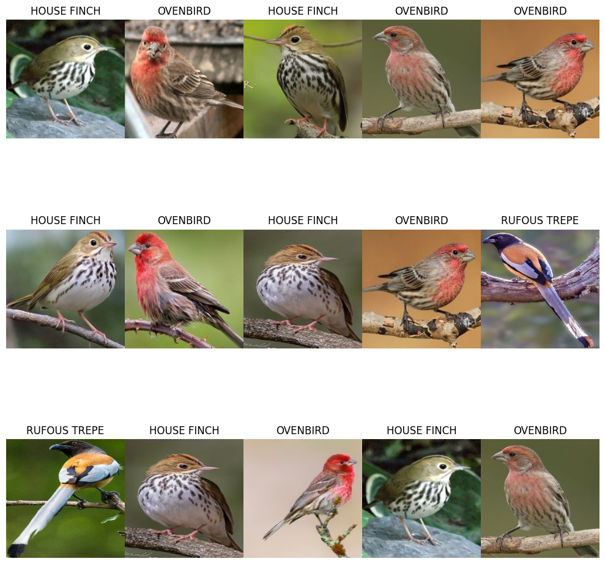

```python
fig, axes = plt.subplots(3,5,figsize=(10, 10))

# Iterate through the training data generator
for i in range(15):
    # Extract the image and labels from the current batch
    image, labels = test_generator.next()

    # Convert the image from float32 to uint8
    image = image[i].astype('uint8')

    label = np.argmax(labels[i])

    axes[i // 5, i % 5].imshow(image)
    axes[i // 5, i % 5].set_title(img_labels[label])
    axes[i // 5, i % 5].axis('off')

plt.tight_layout()
plt.subplots_adjust(wspace=0, hspace=0.2)
plt.show()
```

5. Defining a Full Model

```python
inputs = keras.Input(shape=(224, 224, 3))
x = keras.applications.vgg16.preprocess_input(inputs)
x = conv_base(x)
x = layers.Flatten()(x)
x = layers.Dense(128)(x)
outputs = layers.Dense(3, activation="softmax")(x)
model = keras.Model(inputs, outputs)
```

Model Summary

```python
model.summary()
```

```
Model: "model_1"
_________________________________________________________________
 Layer (type)                Output Shape              Param #
=================================================================
 input_4 (InputLayer)        [(None, 224, 224, 3)]     0

 tf.__operators__.getitem (  (None, 224, 224, 3)       0
 SlicingOpLambda)

 tf.nn.bias_add (TFOpLambda  (None, 224, 224, 3)       0
 )

 vgg16 (Functional)          (None, 7, 7, 512)         14714688

 flatten (Flatten)           (None, 25088)             0

 dense_2 (Dense)             (None, 128)               3211392

 dense_3 (Dense)             (None, 3)                 387

=================================================================
Total params: 17926467 (68.38 MB)
Trainable params: 3211779 (12.25 MB)
Non-trainable params: 14714688 (56.13 MB)
_________________________________________________________________
```

Configure the model for Training

```python
model.compile(loss="binary_crossentropy",
              optimizer="adam",
              metrics=["accuracy"])
```

6 .Train the full model (while the VGG16 weights are frozen)

```python
history = model.fit(
    train_generator,
    epochs=5,
    validation_data=(validation_generator))
```

Plot the results

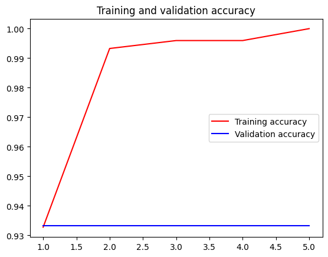

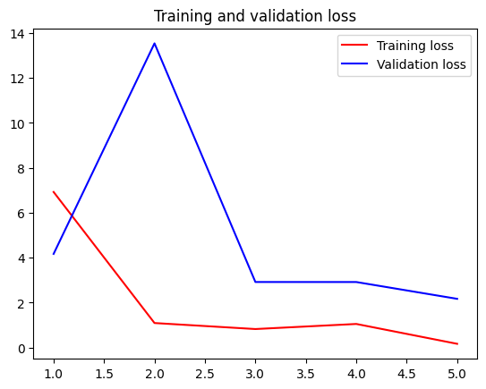

```python
acc = history.history["accuracy"]
val_acc = history.history["val_accuracy"]
loss = history.history["loss"]
val_loss = history.history["val_loss"]
epochs = range(1, len(acc) + 1)
plt.plot(epochs, acc, "r", label="Training accuracy")
plt.plot(epochs, val_acc, "b", label="Validation accuracy")
plt.title("Training and validation accuracy")
plt.legend()
plt.figure()
plt.plot(epochs, loss, "r", label="Training loss")
plt.plot(epochs, val_loss, "b", label="Validation loss")
plt.title("Training and validation loss")
plt.legend()
plt.show()
```

Fine-tuning a pretrained model

```python
conv_base.summary()
```

```
Model: "vgg16"
_________________________________________________________________
 Layer (type)                Output Shape              Param #
=================================================================
 input_3 (InputLayer)        [(None, 224, 224, 3)]     0

 block1_conv1 (Conv2D)       (None, 224, 224, 64)      1792

 block1_conv2 (Conv2D)       (None, 224, 224, 64)      36928

 block1_pool (MaxPooling2D)  (None, 112, 112, 64)      0

 block2_conv1 (Conv2D)       (None, 112, 112, 128)     73856

 block2_conv2 (Conv2D)       (None, 112, 112, 128)     147584

 block2_pool (MaxPooling2D)  (None, 56, 56, 128)       0

 block3_conv1 (Conv2D)       (None, 56, 56, 256)       295168

 block3_conv2 (Conv2D)       (None, 56, 56, 256)       590080

 block3_conv3 (Conv2D)       (None, 56, 56, 256)       590080

 block3_pool (MaxPooling2D)  (None, 28, 28, 256)       0

 block4_conv1 (Conv2D)       (None, 28, 28, 512)       1180160

 block4_conv2 (Conv2D)       (None, 28, 28, 512)       2359808

 block4_conv3 (Conv2D)       (None, 28, 28, 512)       2359808

 block4_pool (MaxPooling2D)  (None, 14, 14, 512)       0

 block5_conv1 (Conv2D)       (None, 14, 14, 512)       2359808

 block5_conv2 (Conv2D)       (None, 14, 14, 512)       2359808

 block5_conv3 (Conv2D)       (None, 14, 14, 512)       2359808

 block5_pool (MaxPooling2D)  (None, 7, 7, 512)         0

=================================================================
Total params: 14714688 (56.13 MB)
Trainable params: 0 (0.00 Byte)
Non-trainable params: 14714688 (56.13 MB)
_________________________________________________________________
```

```python
model.summary()
```

```
Model: "model_1"
_________________________________________________________________
 Layer (type)                Output Shape              Param #
=================================================================
 input_4 (InputLayer)        [(None, 224, 224, 3)]     0

 tf.__operators__.getitem (  (None, 224, 224, 3)       0
 SlicingOpLambda)

 tf.nn.bias_add (TFOpLambda  (None, 224, 224, 3)       0
 )

 vgg16 (Functional)          (None, 7, 7, 512)         14714688

 flatten (Flatten)           (None, 25088)             0

 dense_2 (Dense)             (None, 128)               3211392

 dense_3 (Dense)             (None, 3)                 387

=================================================================
Total params: 17926467 (68.38 MB)
Trainable params: 3211779 (12.25 MB)
Non-trainable params: 14714688 (56.13 MB)
_________________________________________________________________
```

```python
model.summary()
```

```
Model: "model_1"
_________________________________________________________________
 Layer (type)                Output Shape              Param #
=================================================================
 input_4 (InputLayer)        [(None, 224, 224, 3)]     0

 tf.__operators__.getitem (  (None, 224, 224, 3)       0
 SlicingOpLambda)

 tf.nn.bias_add (TFOpLambda  (None, 224, 224, 3)       0
 )

 vgg16 (Functional)          (None, 7, 7, 512)         14714688

 flatten (Flatten)           (None, 25088)             0

 dense_2 (Dense)             (None, 128)               3211392

 dense_3 (Dense)             (None, 3)                 387

=================================================================
Total params: 17926467 (68.38 MB)
Trainable params: 3211779 (12.25 MB)
Non-trainable params: 14714688 (56.13 MB)
_________________________________________________________________
```

7. "Unfreeze" 4 of the top layers of the model

```python
conv_base.trainable = True
for layer in conv_base.layers[:-4]:
    layer.trainable = False
```

8. Train the full model (with the few additional unfrozen weights)

```python
model.compile(loss="binary_crossentropy",
              optimizer=keras.optimizers.RMSprop(learning_rate=1e-5),
              metrics=["accuracy"])
```

```
WARNING:absl:At this time, the v2.11+ optimizer `tf.keras.optimizers.RMSprop` runs slowly on M1/M2 Macs, please use the legacy Keras optimizer instead, located at `tf.keras.optimizers.legacy.RMSprop`.
```

```python
history1 = model.fit(
    train_generator,
    epochs=5,
    validation_data=(validation_generator))
```

Plotting

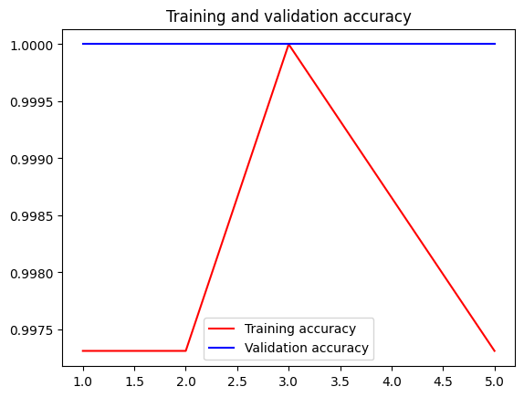

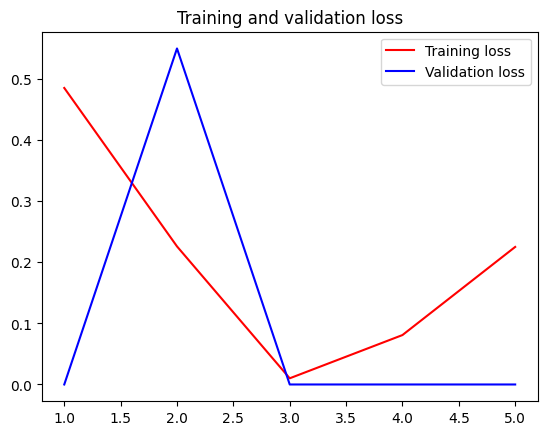

```python
acc = history1.history["accuracy"]
val_acc = history1.history["val_accuracy"]
loss = history1.history["loss"]
val_loss = history1.history["val_loss"]
epochs = range(1, len(acc) + 1)
plt.plot(epochs, acc, "r", label="Training accuracy")
plt.plot(epochs, val_acc, "b", label="Validation accuracy")
plt.title("Training and validation accuracy")
plt.legend()
plt.figure()
plt.plot(epochs, loss, "r", label="Training loss")
plt.plot(epochs, val_loss, "b", label="Validation loss")
plt.title("Training and validation loss")
plt.legend()
plt.show()
```

Test accuracy

```python
test_loss, test_acc = model.evaluate(test_generator)
print(f"Test accuracy: {test_acc:.3f}")
```

```
Test accuracy: 1.000
```

Evaluate the model

```python
def model_eval(model,test_data):
    # Make predictions
    predictions = model.predict(test_data)
    # Convert predictions to class labels
    y_pred = np.argmax(predictions, axis=1)
    # True labels
    y_test = test_generator.classes

    eval = {}
    eval['Accuracy'] = accuracy_score(y_test, y_pred)*100
    eval['Precision'] = precision_score(y_test, y_pred, average='weighted')*100
    eval['Recall'] = recall_score(y_test, y_pred, average='weighted')*100
    eval['f1 score'] = f1_score(y_test, y_pred, average='weighted')*100
    for k,v in eval.items():
        print(f"{k}\t{v:.2f}")
    return y_test,y_pred
```

```python
y_test, y_pred = model_eval(model,test_generator)
```

```
Accuracy	13.33
Precision	13.33
Recall	13.33
f1 score	13.33
```

Precision recall curve and its area under the curve (AUC)

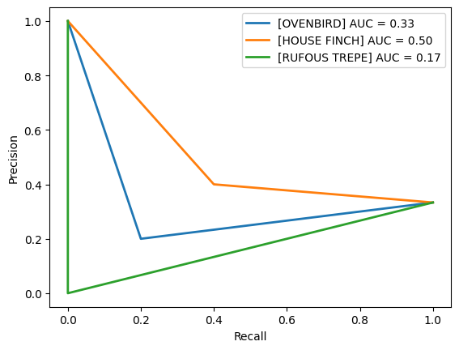

```python
from keras.utils import to_categorical
# prediction labels
pred = model.predict(test_generator)

# True labels
true = test_generator.classes
true = to_categorical(true)
for i in range(3):
    actual = true[:, i]
    predictions = pred[:, i]
    precision, recall, _ = precision_recall_curve(actual, predictions)
    label = f"[{img_labels[i]}] AUC = {auc(recall, precision):.2f}"
    plt.plot(recall,precision,lw=2,label=label)

plt.xlabel("Recall")
plt.ylabel("Precision")
plt.legend()
plt.show()
```

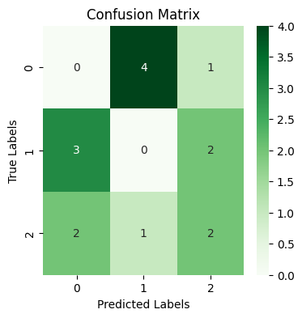

```python
conf_matrix = confusion_matrix(y_test, y_pred)

# Plot the confusion matrix using seaborn heatmap
plt.figure(figsize=(4, 4))
sns.heatmap(conf_matrix, annot=True, cmap='Greens', fmt=".0f",
            xticklabels=img_labels, yticklabels=img_labels)
plt.title('Confusion Matrix')
plt.xlabel('Predicted Labels')
plt.ylabel('True Labels')
plt.show()
```

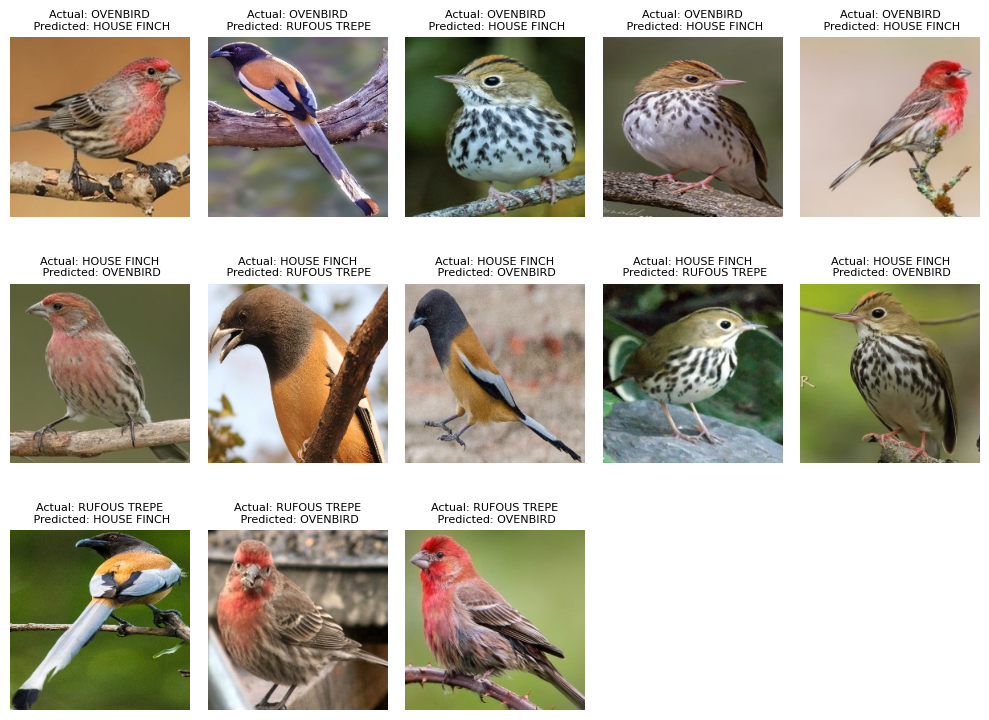

```python
misclassifiedIndices = np.where(y_pred != y_test)[0]

plt.figure(figsize=(10, 10))
for idx,i in enumerate(misclassifiedIndices):

    # doing calculations to find the image in the test_generator
    batchIndex = i // test_generator.batch_size
    batch, _ = test_generator[batchIndex]
    imageIndexInsideBatch = i % test_generator.batch_size
    img = batch[imageIndexInsideBatch] #misclassification image


    actualLabel = img_labels[y_test[i]]
    predictedLabel = img_labels[y_pred[i]]

    plt.subplot(4, 5, idx + 1)
    plt.imshow(img.astype("uint8"))
    plt.title(f"Actual: {actualLabel}\n Predicted: {predictedLabel}",fontsize=8)
    plt.axis("off")
    plt.tight_layout()
    plt.subplots_adjust(wspace=0.1, hspace=0.1)
plt.show()
```